# January 24

Aliaksandr Hubin, Geir Storvik, Jon Olav Vik

2024-01-19

# Cross-validation. Bootstrapping. Bias-variance trade-off. Model selection.

# **Today’s learning goals:**

- Assuming we have several possible models
- How to evaluate and choose the best
  - Train-test splits,
  - Leave out one cross validation,
  - K-fold cross validation,
  - Bootstrap,
  - AIC, BIC combined with search
    - forward
    - backward
    - full enumeration
  - Bayes
- A bit of math, but (**no stress**) technical details are not too critical to follow

# **Recap**

- Two cultures in R: base R and tidyverse (find your own, but today we shall use base R)
- Basic statistical models and tests on Monday
- Simulation and bootstrap on Tuesday

# Regression and MSE

- Regression: $Y=\mu(\boldsymbol x)+\varepsilon$, where the mean $\mu(\boldsymbol x)$ can be linear regression or a neural network, or any **suitable statistical model** really and $\varepsilon$ independent from $\mu(\boldsymbol x)$ with $E[\varepsilon] = 0$ and $Var[\varepsilon] = \sigma^2$
- No normality is assumed here!
- $\widehat Y=\hat \mu(\boldsymbol x)$ based on $\{(\boldsymbol x_1,y_1),...,(\boldsymbol x_n,y_n)\}$
- Assume prediction of $Y_\text{new}$ for new $\boldsymbol x$ from $Y_\text{new}=\mu(\boldsymbol x_\text{new})+\varepsilon$ and $\widehat Y_\text{new} = \hat \mu(\boldsymbol x_\text{new})$,
- Note: $\Rightarrow\varepsilon$ is independent of $\widehat Y_\text{new}$!
- **Evaluation of the model requires an estimate of MSE!**

  $\text{MSE}(\boldsymbol x_\text{new}):=E[(\widehat Y_\text{new}-Y_\text{new})^2]\ =E[(\widehat Y_\text{new}-\mu(\boldsymbol x_\text{new})-\varepsilon)^2]$=[additivity of expectations]

  $E[(\widehat Y-\mu(\boldsymbol x_\text{new}))^2]$ -$2E[(\widehat Y_\text{new} - \mu(\boldsymbol x_\text{new}))\varepsilon]+E[\varepsilon^2]$

  $=E[(\widehat Y_\text{new}-\mu(\boldsymbol x_\text{new}))^2]+\sigma^2$ , the latter ($\sigma^2$) is irreducible error

# Bias-variance trade off

  **Further,** we have $E[(\widehat Y_\text{new}-\mu(\boldsymbol x_\text{new}))^2]$

  $=E[(\widehat Y_\text{new}-E[\widehat Y_\text{new}]+E[\widehat Y_\text{new}]-\mu(\boldsymbol x_\text{new}))^2]$

  $=E[(\widehat Y_\text{new}-E[\widehat Y_\text{new}])^2]+E[(E[\widehat Y_\text{new}]-\mu(\boldsymbol x_\text{new}))^2$

  $+2E[(\widehat Y_\text{new}-E[\widehat Y_\text{new}])(E[\widehat Y_\text{new}]-\mu(\boldsymbol x_\text{new}))]$

  $=\text{Var}[\widehat Y_\text{new}]+(E[\widehat Y_\text{new}]-\mu(\boldsymbol x_\text{new}))^2$ $=\text{Variance}+\text{bias}^2$!!!
- Thus $\text{MSE}(\boldsymbol x_\text{new}) = \text{Variance}+\text{bias}^2 + \text{irreducible error}$

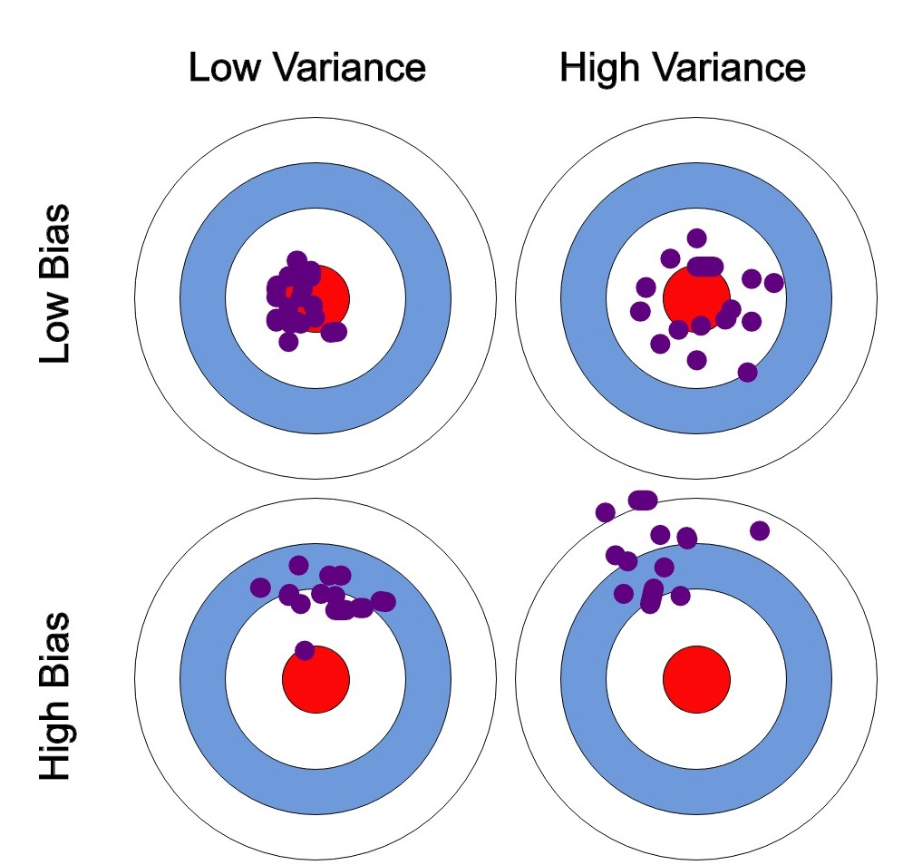

  - **Two sources of error: Bias and Variance.**
  - Ideally we want both small

  **Bias as Modelling Error:**
  - Bias is the error from using a simplification of the real world.
  - Every model involves some degree of simplification.
  - Bias is also known as ‘**modelling error**’.

  **Variance:**
  - Variance - The ‘**estimation error**’.
  - More data points lead to smaller estimation error.
  - More data per parameter reducing estimation error.

  **Trade-off: Bias vs. Variance:**
  - **Classical trade-off between bias and variance**.
  - Difficult to have both ways unless we found **the true data generative mechanism**.
  - Need to balance between bias and variance

  **Conclusion:**
  - Extremes in either direction result in a useless fitted model.
  - *Finding the right balance is crucial in model fitting.*

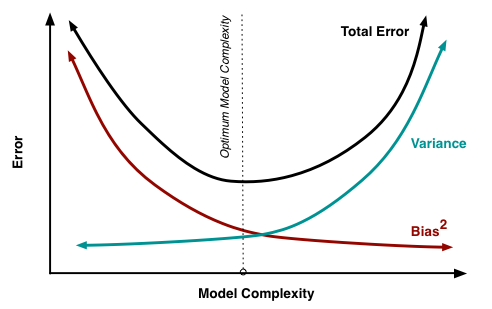

# “Average” over many $\boldsymbol x$’s MSE

- $\text{MSE}(\boldsymbol x)=E[(\widehat Y(\boldsymbol x)-Y(\boldsymbol x))^2]$ only related to one $\boldsymbol x$ (n/b I changed the notation a bit)
- In practice: Want to do predictions on **many** furture $\boldsymbol x$
- We do not know these, but assume they are drawn from som distribution $p(\boldsymbol x)$
- More natural to look at
  $$E[\text{MSE}(\boldsymbol x)]=\int_{\boldsymbol x}\text{MSE}(\boldsymbol
  x)p(\boldsymbol x)d\boldsymbol x=E^{p(\boldsymbol x)}[E[(\widehat
  Y(\boldsymbol x)-Y(\boldsymbol x))^2]]$$

# Estimation of MSE

$$E[\text{MSE}(\boldsymbol
x)]=\int_{\boldsymbol x}\text{MSE}(\boldsymbol x)p(\boldsymbol
x)d\boldsymbol x$$

$$=E_{p(\boldsymbol x)}[E[(\widehat
Y(\boldsymbol x)-Y(\boldsymbol x))^2]]$$

- $p(\boldsymbol x)$ unknown, but we can use the Monte-Carlo approximation:
- $\int_{\boldsymbol x}\text{MSE}(\boldsymbol x)p(\boldsymbol x)d\boldsymbol x$ $\approx \frac{1}{n}\sum_{i=1}^n\text{MSE}(\boldsymbol x_i)$ $=\frac{1}{n}\sum_{i=1}^nE[(\widehat Y(\boldsymbol x_i)-Y(\boldsymbol x_i))^2]\text{ is unbiased}$
- “Obvious estimate”: $\frac{1}{n}\sum_{i=1}^n(\widehat y_i-y_i)^2$
- $Y(\boldsymbol x)$ assumed independent of $\widehat Y(\boldsymbol x)$
- But our estimator $\widehat Y(\boldsymbol x)$ is based on $\{(\boldsymbol x_i,y_i),i=1,...,n\}$
- Thus $\widehat y_i$ depends of $y_i$
- Using “**training”** data to estimate **MSE** **leads to underestimation of error** (aka optimism)

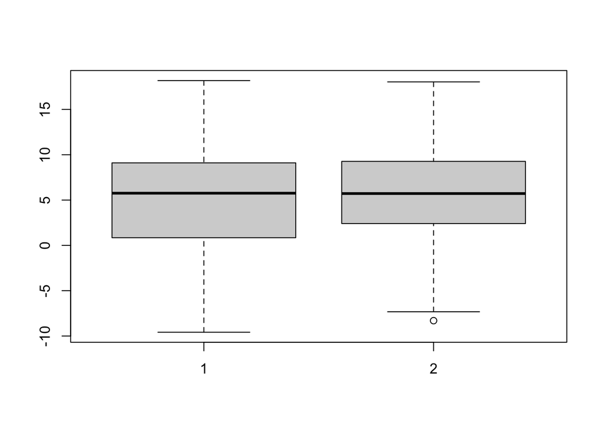

```r
#let us recall yesterday and simulate some data for us to learn what I talked about above
dataset <- data.frame(x = runif(100,1,10))
dataset$y.yesterday <- rnorm(100,dataset$x,5)
dataset$y.tomorrow <- rnorm(100,dataset$x,5)
#same conditional distribution for both days
boxplot(dataset$y.yesterday,dataset$y.tomorrow)
```

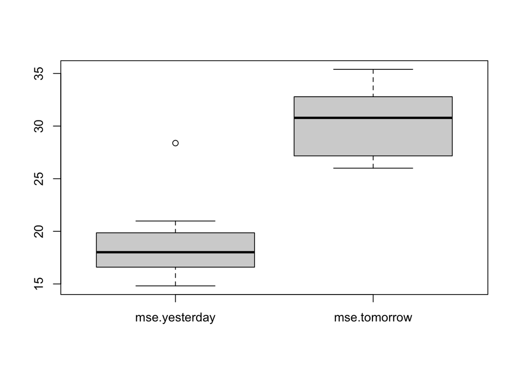

```r
#fit a polinomial or a linear model to a dataset
# p == 0 corresponds to Y = b0 + e
# p == 1 corresponds to Y = b0 + b1*x + e
# p == 2 corresponds to Y = b0 + b1*x + b2*x^2
#...
# p == 5 corresponds to Y = b0 + b1*x + b2*x^2 + b3*x^3 + b4*x^4 + b5*x^5
polinomio <- function(p, dataset) if(p==0) lm(y.yesterday~1,dataset) else lm(y.yesterday~poly(x,p),dataset)

#apply linear model and then polunomials of up to order 23
polinomi <- lapply(0:23, FUN = polinomio, dataset = dataset)

#print(polinomi)

#make predictions for tomorrow for all the polynomial models
y.hat <- lapply(polinomi, predict, data = dataset)

#define the mse
mse.function <- function(y,y.hat) mean((y-y.hat)^2)

mse.yesterday <- sapply(y.hat, mse.function, y = dataset$y.yesterday)
mse.tomorrow <- sapply(y.hat, mse.function, y = dataset$y.tomorrow)

boxplot(cbind(mse.yesterday,mse.tomorrow))
```

Let us plot the results for all polynomials in base R

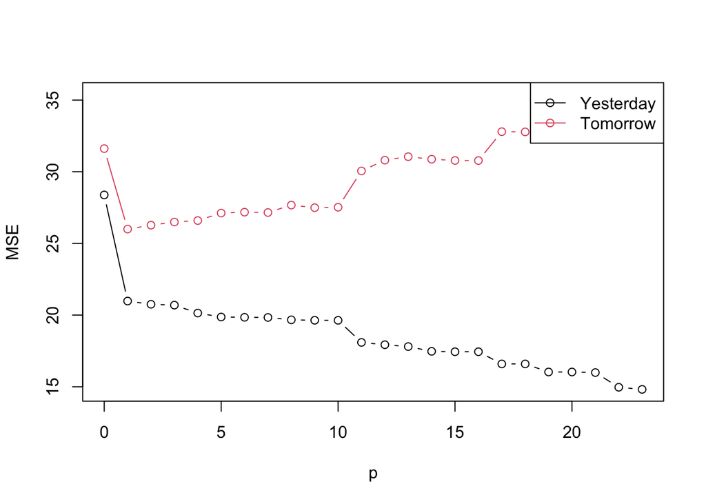

```r
plot(0:23, mse.yesterday, type="b", xlab="p", ylab="MSE", ylim=c(min(c(mse.yesterday,mse.tomorrow)),max(c(mse.yesterday,mse.tomorrow))))
lines(0:23,mse.tomorrow,type = "b", col = 2)
legend("topright", legend = c("Yesterday", "Tomorrow"), col = c(1, 2), pch = 1:1, lty = 1:1)
```

# **Methods for Model Selection**

1. **Main Problem:**
   - Need a separate data set for evaluation or other forms to deal with the *optimism* problem.
2. **Possible Approaches:**
   - One training set and one test set.
   - Cross-validation.
   - Bootstrapping
   - Correcting for underestimation/optimism mathematically.
     - Criteria based on information.

# **Training and Test Sets**

1. **Divide the Full Dataset:**
   - Randomly into two disjoint datasets
     - **Training Set:**
       - Used to estimate/train the model
     - **Test Set:**
       - Used to evaluate the model
2. **Strengths:**
   - Independent dataset for evaluation
   - Easy to apply
   - Easy to understand
3. **Weaknesses:**
   - Reduces the dataset used for training the model
     - Not a problem if huge amounts of data are available
   - If the same test *set is used to choose between* models, the final error measure will be too optimistic (i.e. **overfiting to test data**)!

**Including Validation Set**

1. **Divide the Full Data-set:**
   - Randomly into three disjoint data-sets
     - **Training Set:**
       - Used to estimate/train the model
     - **Validation Set:**
       - Used to select the model
     - **Test Set:**
       - Used to evaluate the final model
     - **Weakness:**
       - **Requires large data-sets!**

```r
library(ISLR)

head(Default)
```

```
##   default student   balance    income
## 1      No      No  729.5265 44361.625
## 2      No     Yes  817.1804 12106.135
## 3      No      No 1073.5492 31767.139
## 4      No      No  529.2506 35704.494
## 5      No      No  785.6559 38463.496
## 6      No     Yes  919.5885  7491.559
```

```r
formel <- balance ~ 1 + as.factor(student) + as.factor(default) + poly(income,8)
fit.lm <- lm(formel,data=Default)
summary(fit.lm)
```

```
##
## Call:
## lm(formula = formel, data = Default)
##
## Residuals:
##      Min       1Q   Median       3Q      Max
## -1023.17  -326.94     1.24   312.23  1646.72
##
## Coefficients:
##                       Estimate Std. Error t value Pr(>|t|)
## (Intercept)            740.428      7.319 101.162   <2e-16 ***
## as.factor(student)Yes  217.681     19.623  11.093   <2e-16 ***
## as.factor(default)Yes  926.784     24.746  37.452   <2e-16 ***
## poly(income, 8)1       447.072    807.070   0.554   0.5796
## poly(income, 8)2      -328.199    541.808  -0.606   0.5447
## poly(income, 8)3      -538.388    444.929  -1.210   0.2263
## poly(income, 8)4       918.022    476.886   1.925   0.0543 .
## poly(income, 8)5       602.787    450.090   1.339   0.1805
## poly(income, 8)6        13.305    449.747   0.030   0.9764
## poly(income, 8)7       629.415    452.939   1.390   0.1647
## poly(income, 8)8        96.070    443.586   0.217   0.8285
## ---
## Signif. codes:  0 '***' 0.001 '**' 0.01 '*' 0.05 '.' 0.1 ' ' 1
##
## Residual standard error: 443.6 on 9989 degrees of freedom
## Multiple R-squared:  0.1599, Adjusted R-squared:  0.1591
## F-statistic: 190.2 on 10 and 9989 DF,  p-value: < 2.2e-16
```

```r
#In-sample prediction error
y.pred <- predict(fit.lm,Default)
RMSE.insamp <- sqrt(mean((Default$balance-y.pred)^2))
print(RMSE.insamp)
```

```
## [1] 443.3274
```

```r
#out of sample prediction error
set.seed(2)
n <- nrow(Default)
ind <- sample(1:n,n/2,replace=FALSE)
fit <- lm(formel,data=Default[ind,])
pred <- predict(fit,Default[-ind,])
RMSE.test <- sqrt(mean((Default$balance[-ind]-pred)^2))
cat(RMSE.insamp,RMSE.test)
```

```
## 443.3274 445.877
```

```r
#Splitting into train and test, repeating several times
n <- nrow(Default)
B <- 20
RMSE.train.test <- rep(NA,B)
for(b in 1:B)
{
  ind <- sample(1:n,n/2,replace = FALSE)
  fit <- lm(formel,data = Default[ind,])
  pred <- predict(fit,Default[-ind,])
  RMSE.train.test[b] <- sqrt(mean((Default$balance[-ind]-pred)^2))
}
```

Another plot in base R

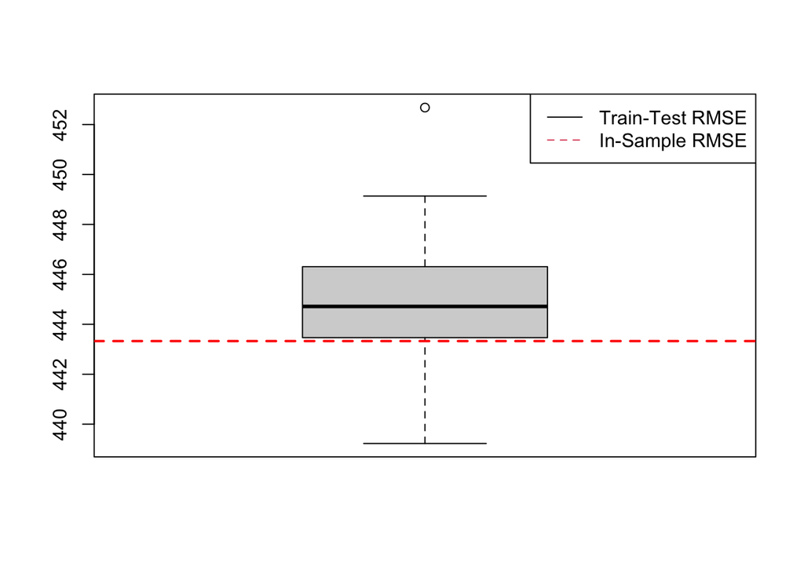

```r
boxplot(RMSE.train.test)
abline(h = RMSE.insamp, col = "red", lty = 2, lwd = 2)
legend("topright", legend = c("Train-Test RMSE", "In-Sample RMSE"), col = c(1, 2), lty = 1:2)
```

# **Leave-One-Out Cross-Validation**

**Leave-One-Out Cross-Validation**

     $\widehat{\text{MSE}}_{LOO} =1/n\sum_{i=1}^n(y_i-\hat y_{-i})^2$
4. **Strengths:**
   - Using (almost) all data for training.
   - Using all data as test.
5. **Weaknesses:**
   - Using (slightly) different models for each prediction.
   - Computationally intensive (i am not using mclapply on purpose to show that!).

```r
n <- nrow(Default)
print(n)
```

```
## [1] 10000
```

```r
y.cv <- rep(NA,n)
for(i in 1:n)
{
  f <- lm(formel,data=Default[-i,])
  y.cv[i] <- predict(f,Default[i,])
}

RMSE.loo <- sqrt(mean((Default$balance-y.cv)^2))
cat("In sample was ", RMSE.insamp, "and LOO-CV is ",RMSE.loo)
```

```
## In sample was  443.3274 and LOO-CV is  443.8078
```

Let us add to our plot

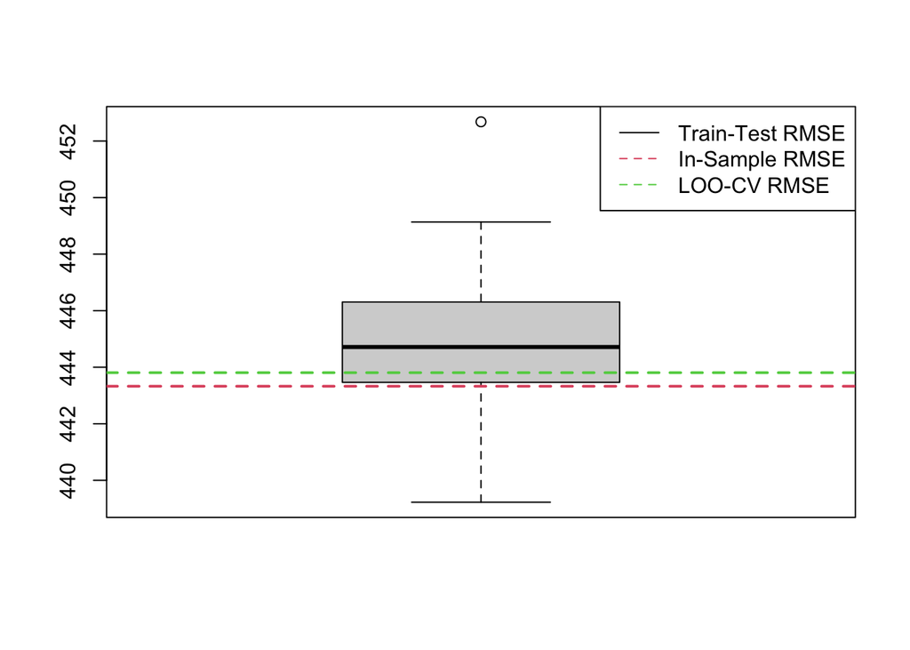

```r
boxplot(RMSE.train.test)
abline(h = RMSE.insamp, col = 2, lty = 2, lwd = 2)
abline(h = RMSE.loo, col = 3, lty = 2, lwd = 2)
legend("topright", legend = c("Train-Test RMSE", "In-Sample RMSE", "LOO-CV RMSE"), col = c(1, 2, 3), lty = c(1,2,2))
```

# $K$**-Folded Cross-Validation**

1. **Data Split:**
   - Divide the data into $K$ equal groups.
2. **Observation Prediction:**
   - For an observation $y_i$ that belongs to group $k_i$, construct $\hat y_i^K$ by using data from all groups **except group** $k_i$
3. **Estimate Mean Squared Error (MSE):**
   - Use the formula:

     $\widehat{\text{MSE}}_{CV-K}=1/n\sum_{i=1}^n(y_i-\hat y_{-i}^K)^2$
4. **Strengths (Compared to LOO-CV):**
   - Only need to train $K$ models, less computationally intensive.
   - All observations are still used as tests.
5. **Weaknesses:**
   - Using **more** differing models for each prediction.

```r
#K-fold CV
K <- 5
nk <- n/K
RMSE.Kcv <- rep(0,K)

ind <- 1:n
for(k in 1:K)
{
  ind.keep <- ind[(k-1)*nk + 1:nk]
  f <- lm(formel,data=Default[-ind.keep,])
  pred.K <- predict(f,Default[ind.keep,])
  RMSE.Kcv[k] <- sqrt(mean((Default$balance[ind.keep]-pred.K)^2))
}


cat("In sample was ", RMSE.insamp, ", LOO-CV was ",RMSE.loo, "and K-fold-CV is ",mean(RMSE.Kcv))
```

```
## In sample was  443.3274 , LOO-CV was  443.8078 and K-fold-CV is  443.8451
```

And let us plot that

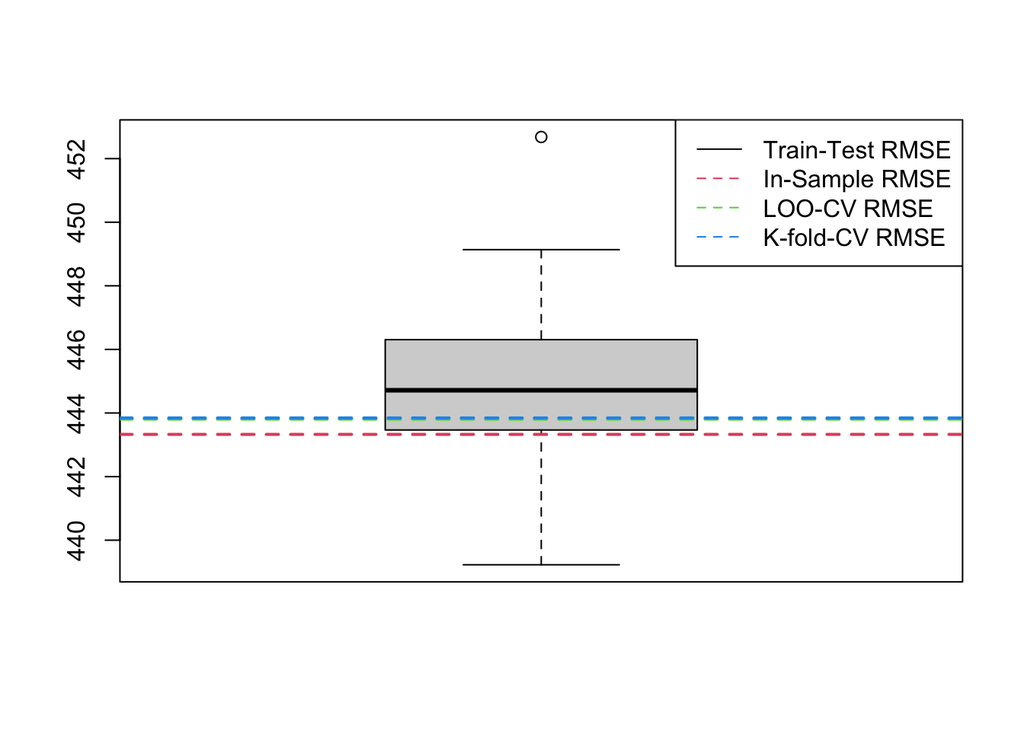

```r
boxplot(RMSE.train.test)
abline(h = RMSE.insamp, col = 2, lty = 2, lwd = 2)
abline(h = RMSE.loo, col = 3, lty = 2, lwd = 2)
abline(h = mean(RMSE.Kcv), col = 4, lty = 2, lwd = 2)
legend("topright", legend = c("Train-Test RMSE", "In-Sample RMSE", "LOO-CV RMSE", "K-fold-CV RMSE"), col = c(1, 2, 3, 4), lty = c(1,2,2,2))
```

# **Bootstrap evaluation of out-of-Sample (R)MSE**

1. **Bootstrap Method:**
   - Resample training data with replacement from the original dataset.
   - Use the data that did not end up in training set as the test set
2. **Observation Prediction:**
   - For each bootstrap sample, fit the model on the training set and evaluate performance on the corresponding test set.
3. **Estimate Out-of-Sample MSE:**
   - Use the formula:

     $\widehat{\text{MSE}}_{Bootstrap} =1/B\sum_{b = 1}^{B}1/n_b\sum_{i=1}^{n_b}(y_i-\hat y_{i}^b)^2$
   - where $B$ is the number of bootstrap samples.
4. **Strengths:**
   - Flexible and applicable to various models.
   - Does not assume a specific data split.
   - Gives a full distribution of the MSE
5. **Weaknesses:**
   - Computationally intensive for large **datasets**.

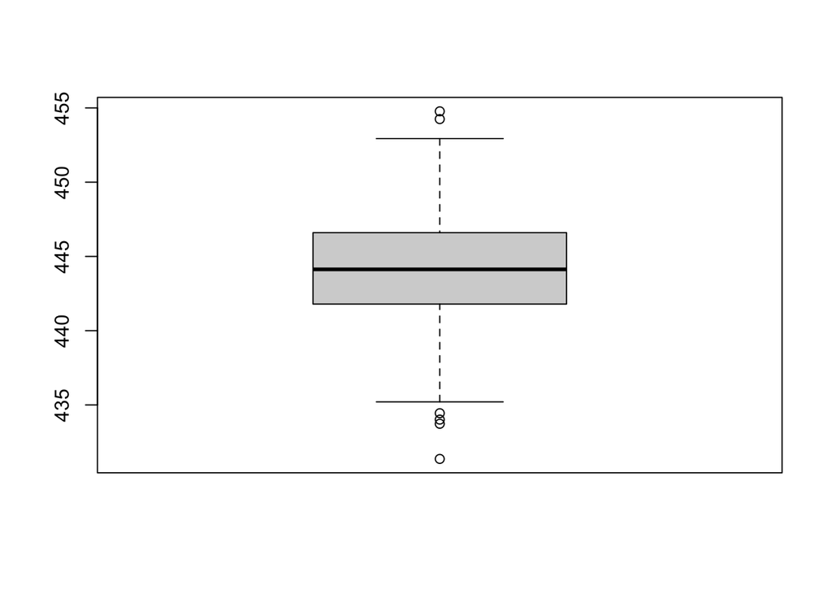

```r
# Bootstrap Validation with Out-of-Bag Predictions
B <- 1000  # Number of bootstrap samples
RMSE.bootstrap <- rep(0, B)

set.seed(123)  # Set seed for reproducibility

for (b in 1:B) {

  ind <- sample(1:n, n, replace = TRUE)  # Bootstrap sampling with replacement
  ind_out_of_bag <- setdiff(1:n, ind)  # Indices not in the current bootstrap training set

  f <- lm(formel, data = Default[ind,])  # Fit model using bootstrap sample
  pred.bootstrap <- predict(f, Default[ind_out_of_bag,])  # Make predictions for out-of-bag indices

  RMSE.bootstrap[b] <- sqrt(mean((Default$balance[ind_out_of_bag] - pred.bootstrap)^2))
}

boxplot(RMSE.bootstrap)
```

```r
cat("In sample was ", RMSE.insamp, ", LOO-CV was ", RMSE.loo, "and Bootstrap Validation is ", mean(RMSE.bootstrap))
```

```
## In sample was  443.3274 , LOO-CV was  443.8078 and Bootstrap Validation is  444.1618
```

and let us plot the graphs

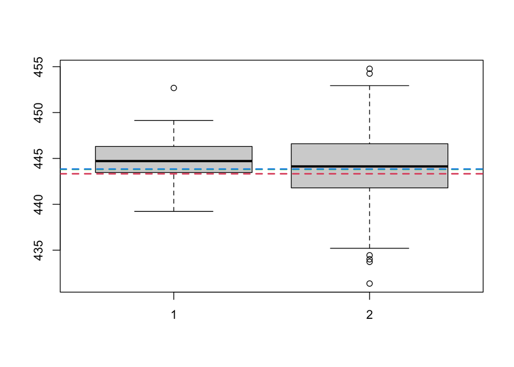

```r
boxplot(RMSE.train.test,RMSE.bootstrap)
abline(h = RMSE.insamp, col = 2, lty = 2, lwd = 2)
abline(h = RMSE.loo, col = 3, lty = 2, lwd = 2)
abline(h = mean(RMSE.Kcv), col = 4, lty = 2, lwd = 2)
```

not too large difference between in sample errors and our more advanced methods here, but even more flexible methods like higher order polynomials or neural networks would typically suffer from the “red” line being far below other lines in our box-plot.

# **Criteria-Based Methods**

- **Within-Sample Estimate:**
  - $MSE = 1/n\sum_{i=1}^n(y_i - \hat y_i)^2$ is underestimated.
- **Regression with Gaussian Noise:**

  $\log L(\hat\theta) =\sum_{i=1}^n[-0.5\log(2\pi)-0.5\log(\hat\sigma^2)-0.5(y_i-\hat y_i)^2] =\text{Const.}-0.5n\log(\hat\sigma^2)-0.5\sum_{i=1}(y_i-\hat y_i)^2$
- **General Case:**
  - $\log L(\hat\theta)$ will overestimate the true $\log L(\theta^{true})$.
- **Correction:**
  - Can we correct for this?
  - Information-based criteria:

    $\text{IC} = -2\log L(\hat\theta)+\text{penalty}(p), \quad p=|\theta|$
- **Model Selection Criteria:**
  - Different choices of penalty identify different **model selection** criteria.
- **Penalty Consideration:**
  - Penalty should increase with $p$.

# Some popular IC

**AIC:**

- $\text{AIC}=-2\log(L(\hat{\boldsymbol\theta}))+2|\boldsymbol\theta|$
- Will typically include too many variables.

**BIC:**

- $\text{BIC} = -2\log(L(\hat{\boldsymbol\theta})) + \log(n)|\boldsymbol\theta|$.
- Penalizes more complex models **harder**.

**AIC and BIC:**

- Can also be used **outside** linear models.

# **Variable Selection**

Let us take a look at an example in R

```r
#Hitters data
library(ISLR)


data(Hitters)
head(Hitters)
```

```
##                   AtBat Hits HmRun Runs RBI Walks Years CAtBat CHits CHmRun
## -Andy Allanson      293   66     1   30  29    14     1    293    66      1
## -Alan Ashby         315   81     7   24  38    39    14   3449   835     69
## -Alvin Davis        479  130    18   66  72    76     3   1624   457     63
## -Andre Dawson       496  141    20   65  78    37    11   5628  1575    225
## -Andres Galarraga   321   87    10   39  42    30     2    396   101     12
## -Alfredo Griffin    594  169     4   74  51    35    11   4408  1133     19
##                   CRuns CRBI CWalks League Division PutOuts Assists Errors
## -Andy Allanson       30   29     14      A        E     446      33     20
## -Alan Ashby         321  414    375      N        W     632      43     10
## -Alvin Davis        224  266    263      A        W     880      82     14
## -Andre Dawson       828  838    354      N        E     200      11      3
## -Andres Galarraga    48   46     33      N        E     805      40      4
## -Alfredo Griffin    501  336    194      A        W     282     421     25
##                   Salary NewLeague
## -Andy Allanson        NA         A
## -Alan Ashby        475.0         N
## -Alvin Davis       480.0         A
## -Andre Dawson      500.0         N
## -Andres Galarraga   91.5         N
## -Alfredo Griffin   750.0         A
```

```r
#??Hitters to see more

#remove the missing data
sum(is.na(Hitters$Salary))
```

```
## [1] 59
```

```r
Hitters <- na.omit(Hitters)
dim(Hitters)
```

```
## [1] 263  20
```

```r
n <- nrow(Hitters)
fit.lm <- lm(Salary~.,data=Hitters)
summary(fit.lm)
```

```
##
## Call:
## lm(formula = Salary ~ ., data = Hitters)
##
## Residuals:
##     Min      1Q  Median      3Q     Max
## -907.62 -178.35  -31.11  139.09 1877.04
##
## Coefficients:
##               Estimate Std. Error t value Pr(>|t|)
## (Intercept)  163.10359   90.77854   1.797 0.073622 .
## AtBat         -1.97987    0.63398  -3.123 0.002008 **
## Hits           7.50077    2.37753   3.155 0.001808 **
## HmRun          4.33088    6.20145   0.698 0.485616
## Runs          -2.37621    2.98076  -0.797 0.426122
## RBI           -1.04496    2.60088  -0.402 0.688204
## Walks          6.23129    1.82850   3.408 0.000766 ***
## Years         -3.48905   12.41219  -0.281 0.778874
## CAtBat        -0.17134    0.13524  -1.267 0.206380
## CHits          0.13399    0.67455   0.199 0.842713
## CHmRun        -0.17286    1.61724  -0.107 0.914967
## CRuns          1.45430    0.75046   1.938 0.053795 .
## CRBI           0.80771    0.69262   1.166 0.244691
## CWalks        -0.81157    0.32808  -2.474 0.014057 *
## LeagueN       62.59942   79.26140   0.790 0.430424
## DivisionW   -116.84925   40.36695  -2.895 0.004141 **
## PutOuts        0.28189    0.07744   3.640 0.000333 ***
## Assists        0.37107    0.22120   1.678 0.094723 .
## Errors        -3.36076    4.39163  -0.765 0.444857
## NewLeagueN   -24.76233   79.00263  -0.313 0.754218
## ---
## Signif. codes:  0 '***' 0.001 '**' 0.01 '*' 0.05 '.' 0.1 ' ' 1
##
## Residual standard error: 315.6 on 243 degrees of freedom
## Multiple R-squared:  0.5461, Adjusted R-squared:  0.5106
## F-statistic: 15.39 on 19 and 243 DF,  p-value: < 2.2e-16
```

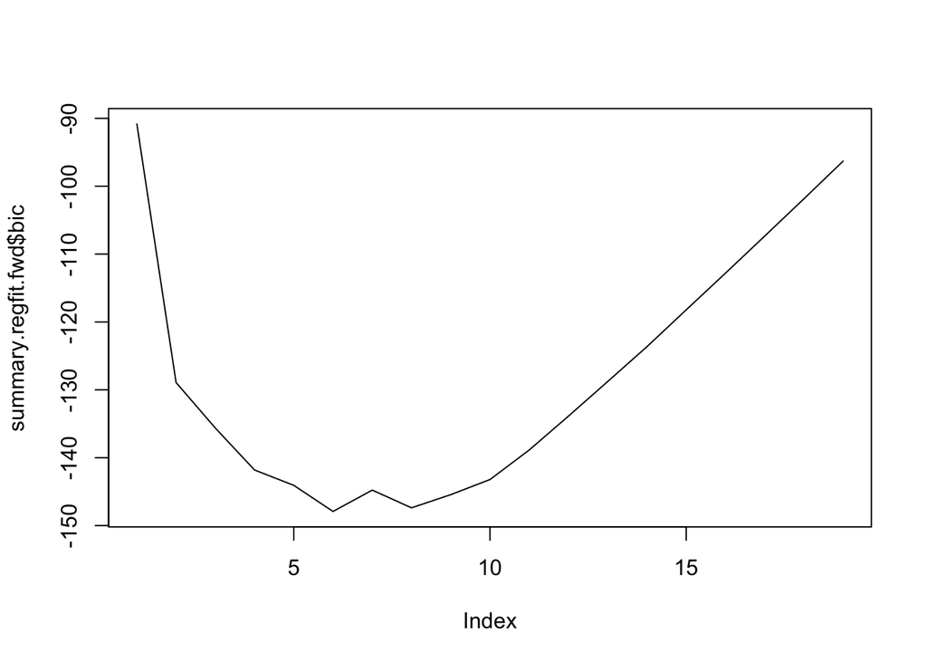

```r
library(leaps)
#Forward selection
nvmax <- 20
# Since this function returns separate best models of all sizes up to nvmax and since different model selection criteria such as AIC, BIC, #... differ only in how models of different sizes are compared, the results do not depend on the choice of cost-complexity tradeoff.
regfit.fwd <- regsubsets(Salary~.,data=Hitters,nvmax=nvmax,method="forward") # to change to backward, use method = "backward"

summary.regfit.fwd = summary(regfit.fwd)

plot(summary.regfit.fwd$bic,type="l")
```

```r
#aic
summary.regfit.fwd$aic <- summary.regfit.fwd$bic-log(n)*(c(1:nvmax)+2)+2*(c(1:nvmax)+2)
```

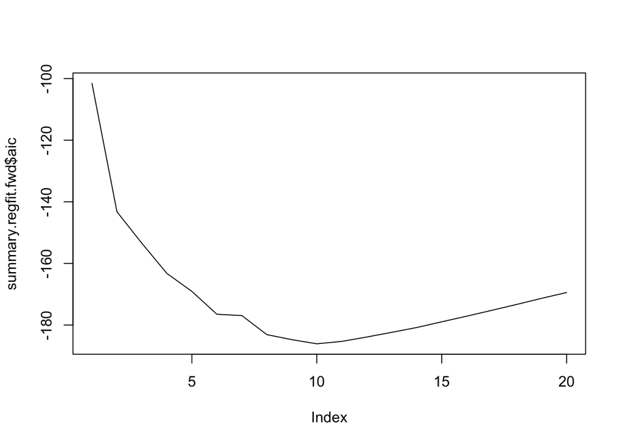

```r
plot(summary.regfit.fwd$aic,type="l")
```

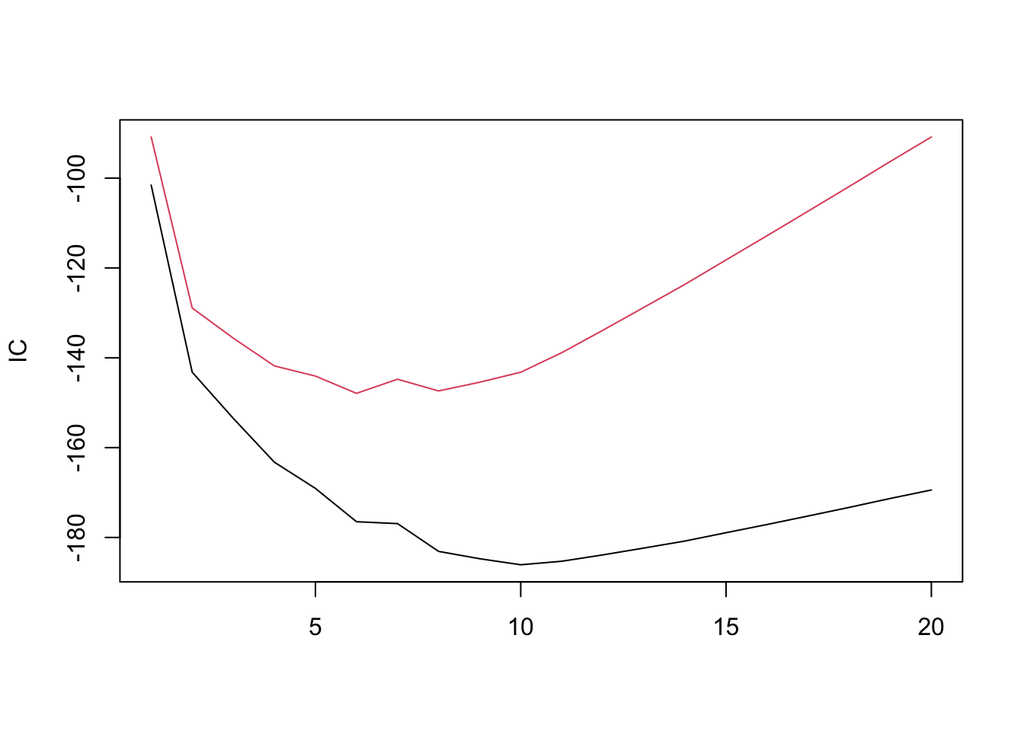

```r
matplot(cbind(summary.regfit.fwd$aic,summary.regfit.fwd$bic),type="l",lty=1,ylab = "IC")
```

```r
#best models
p.aic <- which.min(summary.regfit.fwd$aic)
p.bic <- which.min(summary.regfit.fwd$bic)
```

and plot the selected number of variables

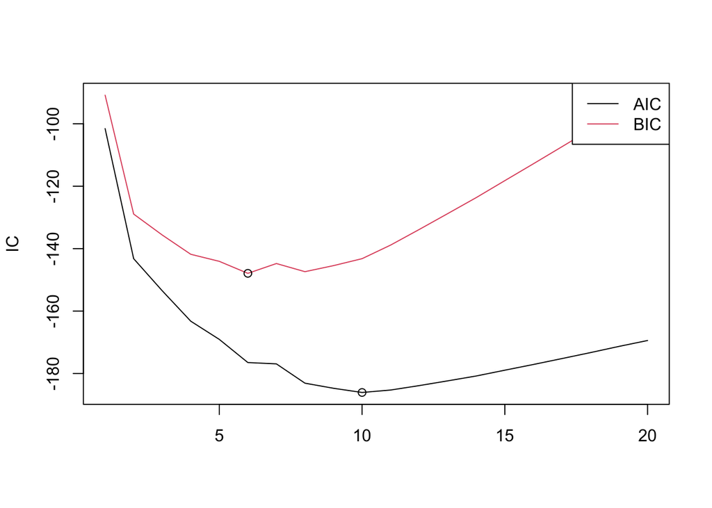

```r
matplot(cbind(summary.regfit.fwd$aic,summary.regfit.fwd$bic),type="l",lty=1,ylab = "IC")
points(c(p.aic,p.bic),
       c(summary.regfit.fwd$aic[p.aic],summary.regfit.fwd$bic[p.bic]))
legend("topright",c("AIC","BIC"),lty=1,col=1:2)
```

let us allow for interactions

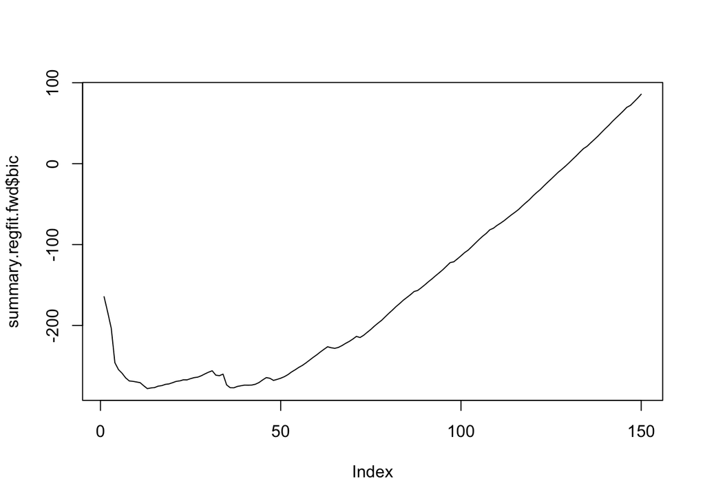

```r
#now include interactions
nvmax <- 150
regfit.fwd <- regsubsets(Salary~.^2-NewLeague^2,data=Hitters,nvmax=nvmax,method="forward")
summary.regfit.fwd <- summary(regfit.fwd)


#bic
plot(summary.regfit.fwd$bic,type="l")
```

```r
which.min(summary.regfit.fwd$bic)
```

```
## [1] 13
```

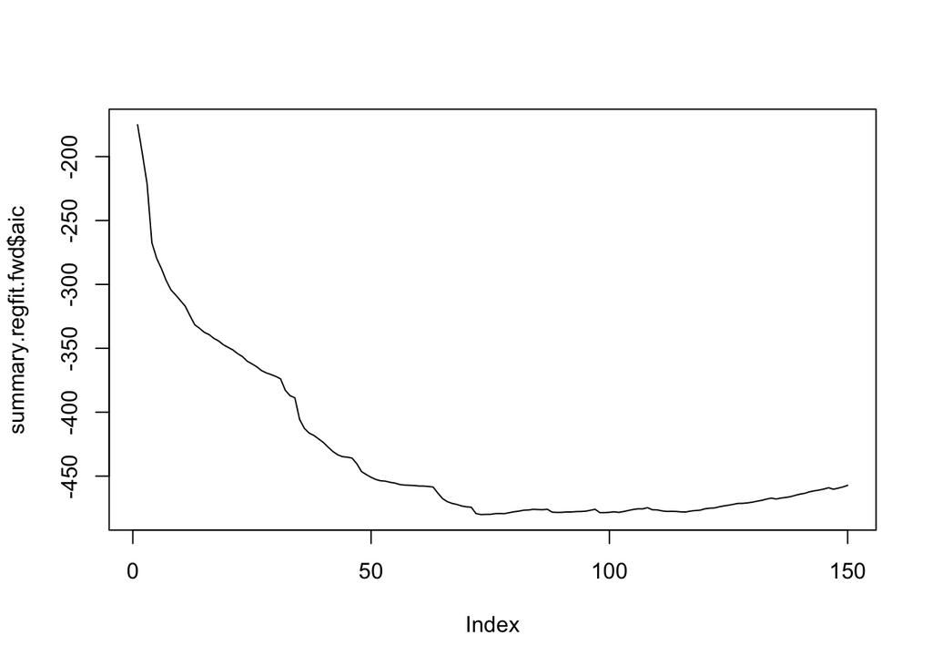

```r
#aic
summary.regfit.fwd$aic = summary.regfit.fwd$bic-log(n)*(c(1:nvmax)+2)+2*(c(1:nvmax)+2)
plot(summary.regfit.fwd$aic,type="l")
```

```r
which.min(summary.regfit.fwd$aic)
```

```
## [1] 73
```

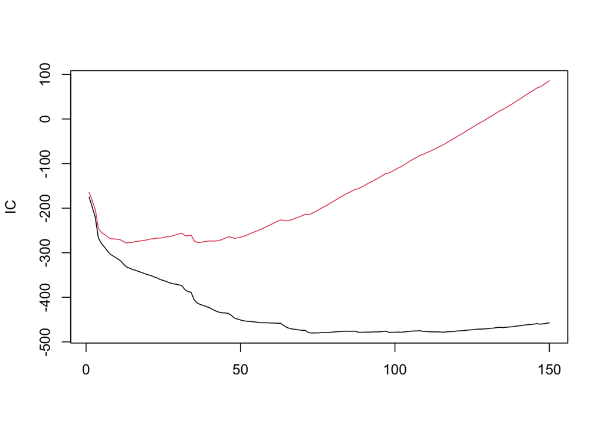

```r
#both
matplot(cbind(summary.regfit.fwd$aic,summary.regfit.fwd$bic),type="l",lty=1,ylab = "IC")
```

```r
#best models
p.aic = which.min(summary.regfit.fwd$aic)
p.bic = which.min(summary.regfit.fwd$bic)
```

and let us plot optimal solutions

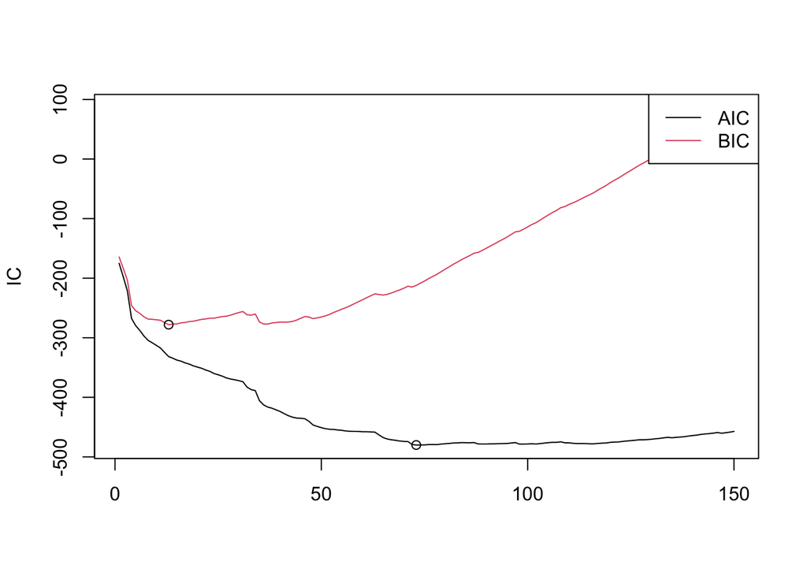

```r
matplot(cbind(summary.regfit.fwd$aic,summary.regfit.fwd$bic),type="l",lty=1,ylab = "IC")
points(c(p.aic,p.bic),
       c(summary.regfit.fwd$aic[p.aic],summary.regfit.fwd$bic[p.bic]))
legend("topright",c("AIC","BIC"),lty=1,col=1:2)
```

# **All Subsets Model Selection**

1. **Consideration of All Subsets:**
   - Evaluate all $2^q$ possible subsets of explanatory variables.
2. **Exhaustive Search:**
   - Assess each subset’s performance based on model selection criteria (e.g., AIC).
3. **Combinatorial Challenge:**
   - Evaluating all subsets becomes impractical for large $q$.
4. **Advantages:**
   - Comprehensive exploration of potential models.
5. **Drawbacks:**
   - Computationally intensive and infeasible for high-dimensional datasets.

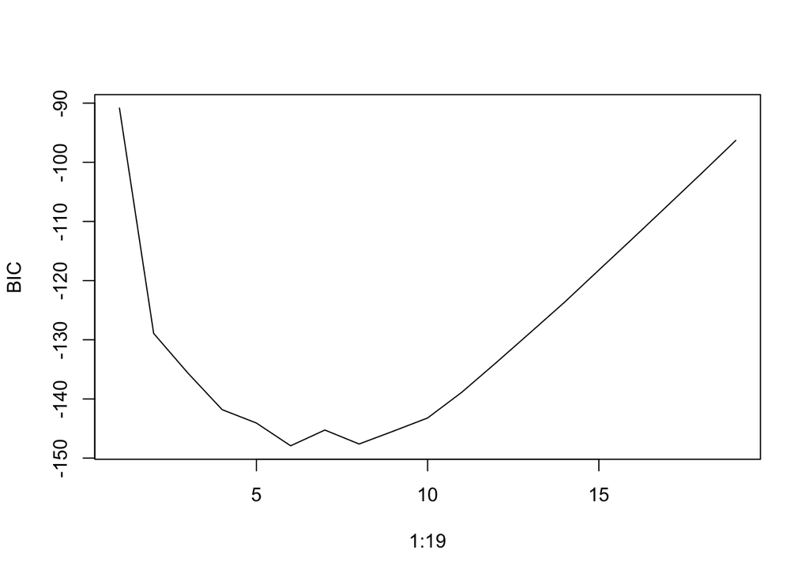

```r
regfit.full <- regsubsets(Salary~.,data=Hitters,nvmax=20, method="exhaustive")
reg.summary <- summary(regfit.full)


plot(1:19, reg.summary$bic,
        type="l",lty=1,ylab="BIC")
```

```r
print(which.min(reg.summary$bic))
```

```
## [1] 6
```

```r
#but already infeasible with interactions
#nvmax <- 150
#regfit.full.int <- regsubsets(Salary~.^2-NewLeague^2,data=Hitters,nvmax=nvmax,method="exhaustive",really.big=T)
```

**Important!** we can no longer rely on p-values for the effects in the best selected model!

# Bayesian **Model Selection**

1. **Bayesian Approach:**
   - Utilizes Bayesian principles for model selection allowing to estimate **probability** of inclusion (selection) for each effect.
   - Thus we have uncertainty regarding the model selection
2. **Posterior Probability:**
   - Assigns a posterior probability to each model from the full subsets but estimated through MCMC, making it feasible!
3. **Model Comparison:**
   - Compares models based on their posterior probabilities.
4. **Advantages:**
   - Incorporates prior knowledge.
   - Provides a probabilistic framework for model evaluation.
5. **Considerations:**
   - Requires specifying prior distributions, which may be subjective (not talk about today).
   - Computationally intensive for complex models (yet better than all subsets selection).
6. **Brief Overview:**
   - Bayesian model selection offers a probabilistic alternative to frequentist criteria.

```r
library(BAS)

regfit.full.bayes <- bas.lm(Salary~.,data=Hitters)
coef(regfit.full.bayes)
```

```
##
##  Marginal Posterior Summaries of Coefficients:
##
##  Using  BMA
##
##  Based on the top  524288 models
##             post mean   post SD     post p(B != 0)
## Intercept    535.92588    19.61881     1.00000
## AtBat         -1.54254     0.94550     0.81766
## Hits           5.73736     3.05968     0.88075
## HmRun          0.03790     1.57438     0.13991
## Runs          -0.09498     1.40037     0.19306
## RBI            0.01594     0.72547     0.14271
## Walks          4.54083     2.33548     0.89628
## Years         -2.15573     6.90064     0.20035
## CAtBat        -0.11966     0.16128     0.50626
## CHits          0.37285     0.63658     0.44683
## CHmRun         0.55025     0.83684     0.45823
## CRuns          0.58586     0.61986     0.59000
## CRBI           0.36727     0.39068     0.58420
## CWalks        -0.41984     0.43160     0.58687
## LeagueN        8.02728    27.62335     0.18289
## DivisionW   -108.69615    51.58573     0.90710
## PutOuts        0.26213     0.08731     0.97385
## Assists        0.06542     0.14409     0.26607
## Errors        -0.10842     1.65089     0.14371
## NewLeagueN     2.03043    22.37598     0.14846
```

now feasible with interactions

```r
regfit.full.bayes.interact <- bas.lm(Salary~.^2-NewLeague^2,data=Hitters)
coef(regfit.full.bayes.interact)
```

```
##
##  Marginal Posterior Summaries of Coefficients:
##
##  Using  BMA
##
##  Based on the top  524288 models
##                       post mean   post SD     post p(B != 0)
## Intercept              5.359e+02   1.544e+01   1.000e+00
## AtBat                 -2.193e-01   4.123e-01   2.664e-01
## Hits                  -2.310e-01   1.344e+00   3.669e-02
## HmRun                 -3.142e-03   1.772e-01   1.102e-03
## Runs                  -2.964e-02   3.721e-01   8.674e-03
## RBI                   -5.447e-03   1.201e-01   3.033e-03
## Walks                 -4.898e-02   5.397e-01   1.153e-02
## Years                  1.418e-02   5.315e-01   1.841e-03
## CAtBat                -8.717e-05   4.132e-03   1.274e-03
## CHits                  1.223e+00   1.309e-01   1.000e+00
## CHmRun                 4.038e-04   3.559e-02   1.015e-03
## CRuns                  3.063e-03   5.072e-02   4.741e-03
## CRBI                  -1.230e-04   1.599e-02   1.245e-03
## CWalks                 6.140e-03   5.220e-02   1.612e-02
## LeagueN                3.208e+00   3.115e+01   1.278e-02
## DivisionW             -2.092e-01   3.997e+00   3.682e-03
## PutOuts               -1.346e-05   2.886e-03   9.967e-04
## Assists                5.911e-04   3.121e-02   1.703e-03
## Errors                 1.131e-06   1.187e-01   8.954e-04
## AtBat:Hits             2.750e-04   1.439e-03   4.219e-02
## AtBat:HmRun            4.359e-06   3.600e-04   1.407e-03
## AtBat:Runs             1.518e-04   1.222e-03   1.801e-02
## AtBat:RBI              2.771e-06   1.932e-04   2.175e-03
## AtBat:Walks            1.734e-04   1.194e-03   2.305e-02
## AtBat:Years            9.250e-07   7.753e-04   9.638e-04
## AtBat:CAtBat          -7.252e-08   6.110e-06   2.696e-03
## AtBat:CHits           -1.974e-07   1.220e-05   1.386e-03
## AtBat:CHmRun           9.822e-06   2.313e-04   3.233e-03
## AtBat:CRuns            9.848e-07   3.765e-05   2.156e-03
## AtBat:CRBI            -2.061e-07   1.980e-05   9.250e-04
## AtBat:CWalks           1.990e-05   1.400e-04   2.247e-02
## AtBat:LeagueN         -1.575e-03   3.366e-02   3.025e-03
## AtBat:DivisionW       -1.103e-03   1.470e-02   6.858e-03
```

[output cut: 142 more lines]

```
## LeagueN:DivisionW     -2.376e-04   1.100e+00   7.653e-04
## LeagueN:PutOuts        2.274e-04   5.991e-03   2.171e-03
## LeagueN:Assists        6.953e-05   4.914e-03   9.233e-04
## LeagueN:Errors         1.183e-03   8.503e-02   7.772e-04
## LeagueN:NewLeagueN     4.879e-02   2.022e+00   1.350e-03
## DivisionW:PutOuts     -1.264e-04   4.342e-03   1.507e-03
## DivisionW:Assists     -3.412e-04   9.933e-03   2.308e-03
## DivisionW:Errors      -5.486e-03   1.730e-01   1.643e-03
## DivisionW:NewLeagueN  -1.235e-02   1.212e+00   7.866e-04
## PutOuts:Assists       -7.063e-07   2.409e-05   1.409e-03
## PutOuts:Errors        -3.218e-06   2.009e-04   9.538e-04
## PutOuts:NewLeagueN     5.615e-05   2.940e-03   9.327e-04
## Assists:Errors        -2.836e-06   2.712e-04   1.157e-03
## Assists:NewLeagueN     5.784e-05   4.607e-03   8.312e-04
## Errors:NewLeagueN      5.583e-04   7.752e-02   7.690e-04
```

Read more on BAS package here https://link.springer.com/article/10.3758/s13428-021-01552-2

## **Exercises - replace loops with sapply/lapply/mclapply**

Replace loops with sapply/lapply/mclapply functions for leave-out-one cross validation, K-fold cross validation, and bootstrap procedure

## **Exercises - classification of bacteria again**

Expand exercise on classification of bacteria, and implement a cross-validation to estimate the CER (classification error rate) (**not RMSE!**). Use K values 1,2,…,10. Compute the CER for each choice of K. Do the same with bootstrapping.

Can you make a boxplot that both illustrates the error for each choice of K and at the same time also the variability between segments? Then do the boxplot for bootstrapping.